# Interpreting logistic regression

Jake Hofman

April 5, 2019

# Read the data

```r
titanic <- read_csv('titanic_train.csv')
```

# Simple model of survival by gender

First, fit a simple model by gender only.

```r
model <- glm(Survived ~ Sex, data = titanic)
tidy(model) %>%
  kable
```

| term | estimate | std.error | statistic | p.value |
| --- | --- | --- | --- | --- |
| (Intercept) | 0.7420382 | 0.0230658 | 32.17052 | 0 |
| Sexmale | -0.5531301 | 0.0286628 | -19.29782 | 0 |

Same model, but no intercept, so we can see both factor levels explicitly.

```r
model <- glm(Survived ~ 0 + Sex, data = titanic)
tidy(model) %>%
  kable()
```

| term | estimate | std.error | statistic | p.value |
| --- | --- | --- | --- | --- |
| Sexfemale | 0.7420382 | 0.0230658 | 32.17052 | 0 |
| Sexmale | 0.1889081 | 0.0170155 | 11.10211 | 0 |

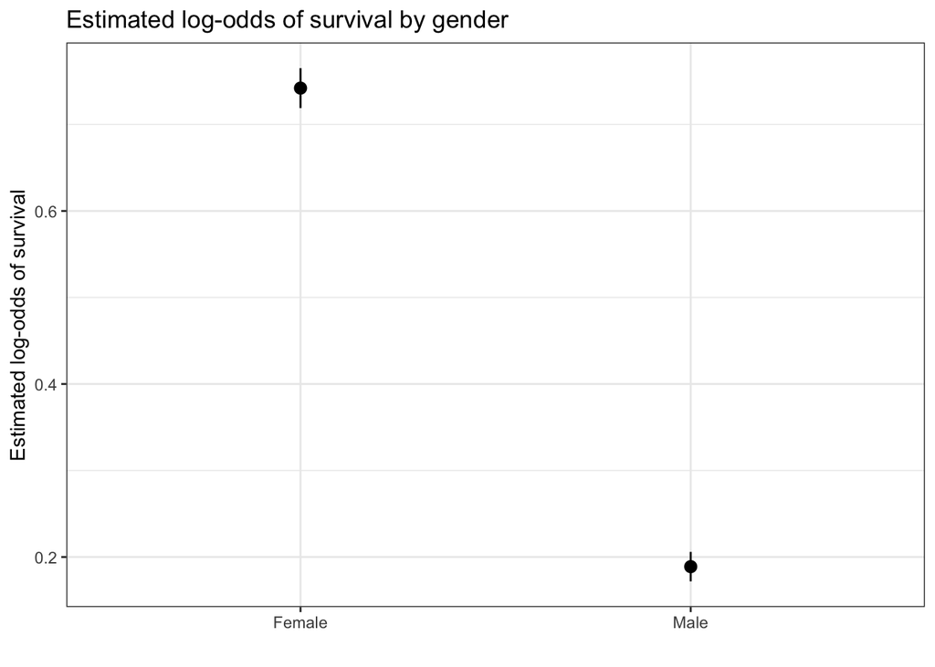

```r
tidy(model) %>%
  ggplot(aes(x = term, y = estimate)) +
  geom_pointrange(aes(ymin = estimate - std.error, ymax = estimate + std.error)) +
  scale_x_discrete(labels = c("Female", "Male")) +
  labs(x = '',
       y = 'Estimated log-odds of survival',
       title = 'Estimated log-odds of survival by gender')
```

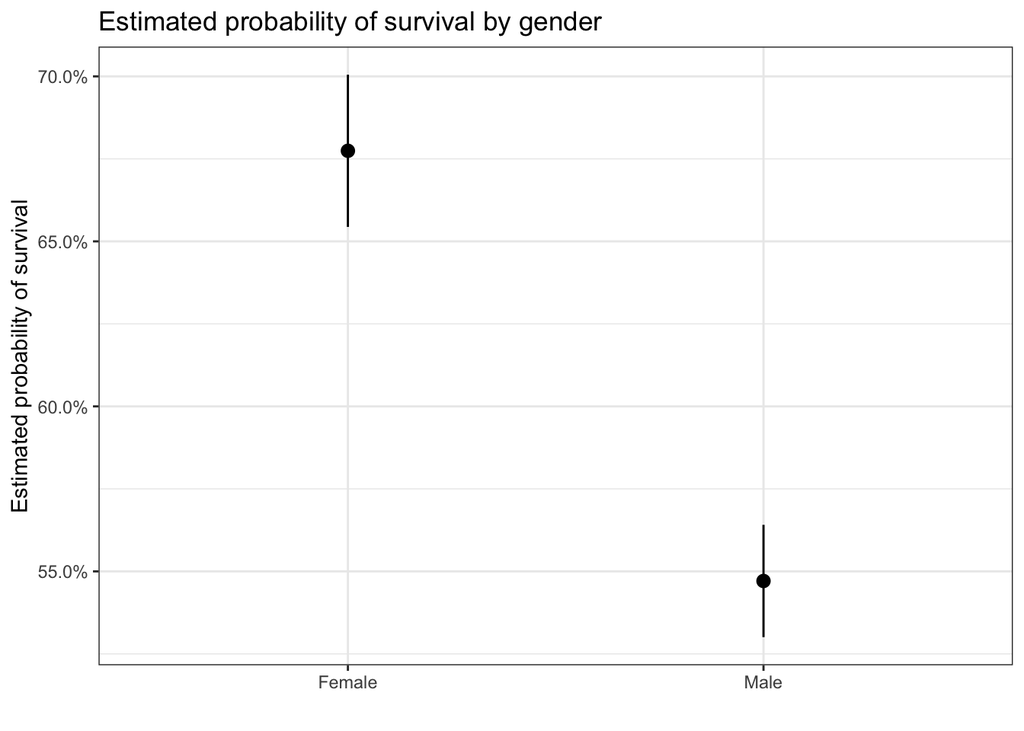

```r
tidy(model) %>%
  mutate(estimate = 1 / (1 + exp(-estimate)),
         lower = 1 / (1 + exp(-(estimate - std.error))),
         upper = 1 / (1 + exp(-(estimate + std.error)))) %>%
  ggplot(aes(x = term, y = estimate)) +
  geom_pointrange(aes(ymin = estimate - std.error, ymax = estimate + std.error)) +
  scale_x_discrete(labels = c("Female", "Male")) +
  scale_y_continuous(labels = percent) +
  labs(x = '',
       y = 'Estimated probability of survival',
       title = 'Estimated probability of survival by gender')
```

# Model with gender and age

Fit a model with age and gender, allowing for quadratic in age.

```r
model <- glm(Survived ~ Sex * (Age + I(Age^2)), data = titanic)
tidy(model) %>%
  kable()
```

| term | estimate | std.error | statistic | p.value |
| --- | --- | --- | --- | --- |
| (Intercept) | 0.6538715 | 0.0872652 | 7.4929271 | 0.0000000 |
| Sexmale | -0.1683430 | 0.1139521 | -1.4773137 | 0.1400362 |
| Age | 0.0037159 | 0.0061848 | 0.6008018 | 0.5481643 |
| I(Age^2) | -0.0000029 | 0.0001008 | -0.0285571 | 0.9772258 |
| Sexmale:Age | -0.0199988 | 0.0075978 | -2.6321672 | 0.0086691 |
| Sexmale:I(Age^2) | 0.0001928 | 0.0001181 | 1.6321291 | 0.1030970 |

Create fake data to predict on using all unique values of gender and age in the dataset.

```r
plot_data <- titanic %>%
  data_grid(Sex, Age)
# add predictions for these fake data
plot_data$pred <- predict(model, plot_data, type = "response")
```

Plot the model’s predictions. This is easier to look at than the coefficients, but doesn’t give us a good sense of how the model and data compare.

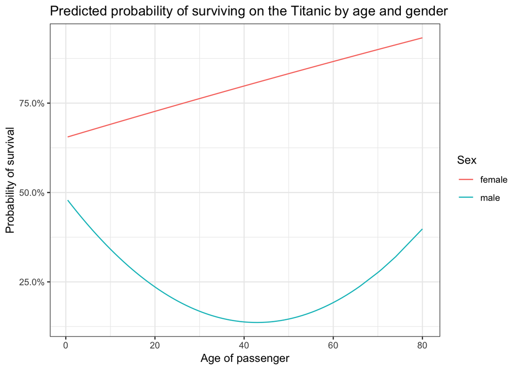

```r
ggplot(plot_data, aes(x = Age, y = pred, color = Sex)) +
  geom_line() +
  scale_y_continuous(labels = percent) +
  labs(x = 'Age of passenger',
       y = 'Probability of survival',
       title = 'Predicted probability of surviving on the Titanic by age and gender')
```

Count the actual fraction of people who survived at each age and gender where we round age to the nearest multiple of 5.

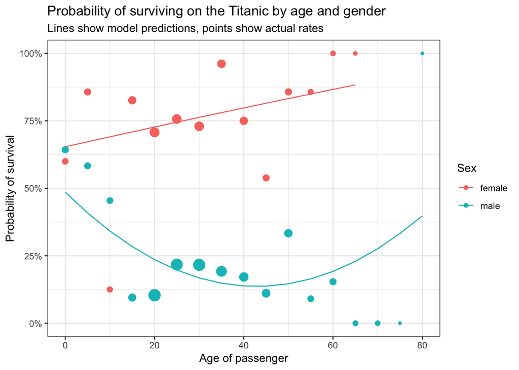

```r
plot_data <- titanic %>%
  mutate(Age = round(Age / 5) * 5) %>%
  group_by(Age, Sex) %>%
  summarize(count = n(),
            actual = mean(Survived))
# add predictions
plot_data$pred <- predict(model, plot_data, type = "response")

# plot predictions and actual survival rates
ggplot(plot_data, aes(x = Age, y = pred, color = Sex)) +
  geom_line() +
  geom_point(aes(x = Age, y = actual, size = count)) +
  scale_size(guide = F) +
  scale_y_continuous(labels = percent) +
  labs(x = 'Age of passenger',
       y = 'Probability of survival',
       title = 'Probability of surviving on the Titanic by age and gender',
       subtitle = 'Lines show model predictions, points show actual rates')
```

# Fancier model with gender and age on limited age range

Filter out ages where we have only a few observations. Then fit a model with age and gender, allowing for cubic in age this time.

```r
model_data <- titanic %>%
  filter(Age <= 65)

model <- glm(Survived ~ Sex * (Age + poly(Age,3)), data = model_data)
tidy(model) %>%
  kable()
```

| term | estimate | std.error | statistic | p.value |
| --- | --- | --- | --- | --- |
| (Intercept) | 0.6541294 | 0.0566936 | 11.5379733 | 0.0000000 |
| Sexmale | -0.3268420 | 0.0733300 | -4.4571396 | 0.0000097 |
| Age | 0.0036205 | 0.0018159 | 1.9937898 | 0.0465637 |
| poly(Age, 3)2 | 0.0349129 | 0.6973372 | 0.0500661 | 0.9600841 |
| poly(Age, 3)3 | 0.3510130 | 0.7192236 | 0.4880443 | 0.6256717 |
| Sexmale:Age | -0.0075282 | 0.0022993 | -3.2741561 | 0.0011121 |
| Sexmale:poly(Age, 3)2 | 1.7329240 | 0.8643180 | 2.0049611 | 0.0453529 |
| Sexmale:poly(Age, 3)3 | -2.4385306 | 0.8743151 | -2.7890754 | 0.0054299 |

Count the actual fraction of people who survived at each age and gender, where we round age to the nearest multiple of 5.

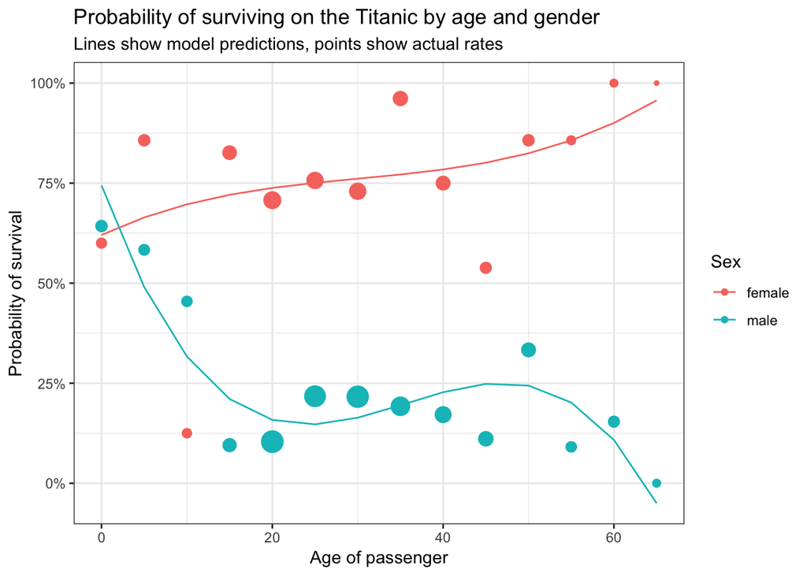

```r
plot_data <- model_data %>%
  mutate(Age = round(Age / 5) * 5) %>%
  group_by(Age, Sex) %>%
  summarize(count = n(),
            actual = mean(Survived))
# add predictions
plot_data$pred <- predict(model, plot_data, type = "response")
# plot predictions and actual survival rates
ggplot(plot_data, aes(x = Age, y = pred, color = Sex)) +
  geom_line() +
  geom_point(aes(x = Age, y = actual, size = count)) +
  scale_size(guide = F) +
  scale_y_continuous(labels = percent) +
  labs(x = 'Age of passenger',
       y = 'Probability of survival',
       title = 'Probability of surviving on the Titanic by age and gender',
       subtitle = 'Lines show model predictions, points show actual rates')
```